# COVID-19 Excess Mortality Analysis

# Objective 3: Evaluate Efficacy of Lockdowns

In this section, we evaluate the effectiveness of lockdowns by comparing lockdown stringency in Ontario to deaths, and analyzing potential correlation.

Create excess deaths data frame to use with stringency index data

```r
DeathData.COVID = DeathData[c(522:(599-5)),c(10:11)]    # take only COVID data
rownames(DeathData.COVID) <- 1:73                   # re-index row names
DeathData.COVID$Actual <- DeathData.2020_2021
DeathData.COVID$Predicted <- actualArima.fcast$mean
DeathData.COVID$Excess <- DeathData.2020_2021 - actualArima.fcast$mean
colnames(DeathData.COVID) <- c("Year","Month","Actual Deaths","Predicted Deaths","Excess Deaths")
DeathData.COVID
```

|  | Year | Month | Actual Deaths | Predicted Deaths | Excess Deaths |
| --- | --- | --- | --- | --- | --- |
| 1 | 2020 | 1 | 2385 | 2435.396 | -50.395693 |
| 2 | 2020 | 1 | 2350 | 2431.162 | -81.161871 |
| 3 | 2020 | 1 | 2275 | 2390.894 | -115.893784 |
| 4 | 2020 | 1 | 2270 | 2373.437 | -103.437163 |
| 5 | 2020 | 2 | 2190 | 2336.339 | -146.338855 |
| 6 | 2020 | 2 | 2185 | 2363.662 | -178.661560 |
| 7 | 2020 | 2 | 2230 | 2313.134 | -83.134363 |
| 8 | 2020 | 2 | 2165 | 2270.707 | -105.707337 |
| 9 | 2020 | 2 | 2065 | 2204.479 | -139.478951 |
| 10 | 2020 | 3 | 2135 | 2196.371 | -61.370725 |

[output cut: 63 more lines]

Stringency index is a a measurement created by the Centre of Excellence on the Canadian Federation used to “measure the relative stringency of policy responses” to the COVID-19 pandemic. The index captures 13 measures by imposed by governments, including travel and gathering restrictions, mask mandates, amongst others.

Data Source: [Centre of Excellence on the Canadian Federation - COVID-19 Stringency Index](https://centre.irpp.org/data/covid-19-provincial-policies/)

Load stringency index data and observe

```r
StringencyData = read.csv("data/ontario_stringency_index_2020_2021.csv", fileEncoding = "UTF-8-BOM") # get data
StringencyData.weekly = StringencyData[seq(1,nrow(StringencyData),7),] # select weekly data

# create lagged stringencyIndex data
# lag by three weeks as 18.5 is the average number of days between first symptoms of COVID and death
# source: https://www.drugs.com/medical-answers/covid-19-symptoms-progress-death-3536264/
laggedStringencyData.weekly <- StringencyData.weekly[c(rep(NA,3), 1:(nrow(StringencyData.weekly)-3)),]
StringencyData.weekly$`Stringency Index -3 Weeks` <- laggedStringencyData.weekly$stringencyIndex # add lagged data to df

StringencyData.weekly = StringencyData.weekly[c(1:73),]       # only take data with corresponding COVID data
rownames(StringencyData.weekly) <- 1:73                       # re-index row names

tail(StringencyData.weekly)
```

|  | date | stringencyIndex | Stringency Index -3 Weeks |
| --- | --- | --- | --- |
| 68 | 2021-04-17 | 58.9 | 47.1 |
| 69 | 2021-04-24 | 73.2 | 54.2 |
| 70 | 2021-05-01 | 73.2 | 58.9 |
| 71 | 2021-05-08 | 73.2 | 58.9 |
| 72 | 2021-05-15 | 73.2 | 73.2 |
| 73 | 2021-05-22 | 73.2 | 73.2 |

Add stringency index to the data frame

```r
DeathData.COVID$`Stringency Index` <- StringencyData.weekly$stringencyIndex
DeathData.COVID$`Stringency Index -3 Weeks` <- StringencyData.weekly$`Stringency Index -3 Weeks`
colnames(DeathData.COVID) <- c("Year","Month","Actual Deaths","Predicted Deaths","Excess Deaths","Stringency Index","Stringency Index -3 Weeks")

DeathData.COVID = DeathData.COVID[c(14:73),]           # take data from the beginning of lockdowns
rownames(DeathData.COVID) <- 1:60                      # re-index row names

tail(DeathData.COVID)
```

|  | Year | Month | Actual Deaths | Predicted Deaths | Excess Deaths | Stringency Index | Stringency Index -3 Weeks |
| --- | --- | --- | --- | --- | --- | --- | --- |
| 55 | 2021 | 4 | 2155 | 2147.235 | 7.764682 | 58.9 | 47.1 |
| 56 | 2021 | 4 | 2185 | 2135.352 | 49.647802 | 73.2 | 54.2 |
| 57 | 2021 | 5 | 2310 | 2154.541 | 155.459015 | 73.2 | 58.9 |
| 58 | 2021 | 5 | 2245 | 2073.980 | 171.019512 | 73.2 | 58.9 |
| 59 | 2021 | 5 | 2175 | 2074.545 | 100.455385 | 73.2 | 73.2 |
| 60 | 2021 | 5 | 2145 | 2073.167 | 71.833340 | 73.2 | 73.2 |

```r
startYear = DeathData.COVID$Year[1]
startMonth = DeathData.COVID$Month[1]

ExcessDeaths.ts <- ts(DeathData.COVID$`Excess Deaths`, start=c(startYear,startMonth), frequency=52)
StringencyIndex.ts <- ts(DeathData.COVID$`Stringency Index -3 Weeks`, start=c(startYear,startMonth), frequency=52)

par(mar = c(5, 4, 4, 4) + 0.3)                                                 # additional space for second y-axis
plot(StringencyIndex.ts, col = 2,ylab = "Lagged Stringency Index (3 Weeks)")   # create first plot
par(new = TRUE)                                                                # add new plot
```

```r
plot(ExcessDeaths.ts, col = 3,                                                 # create second plot without axes
     axes = FALSE, xlab = "", ylab = "")
axis(side = 4, at = pretty(range(ExcessDeaths.ts)))                            # add second axis
```

[figure not shown]

```r
mtext("Excess Deaths", side = 4, line = 3)                                     # add second axis label
legend("topleft", lty = 1, col = c(2,3), legend = c("Stringency Index", "Excess Deaths"))
```

Visually, it appears that there is a negative correlation between the stringency of government measures and excess deaths.

Create correlation between stringency index and excess deaths

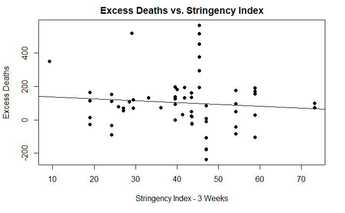

```r
# plot correlation between variables
plot(DeathData.COVID$`Stringency Index -3 Weeks`,DeathData.COVID$`Excess Deaths`,
     pch=16,
     main="Excess Deaths vs. Stringency Index",
     xlab="Stringency Index - 3 Weeks",
     ylab="Excess Deaths")

# fit line
abline(lm(DeathData.COVID$`Excess Deaths` ~ DeathData.COVID$`Stringency Index -3 Weeks`))
```

Observations:

- Scatter plot shows negative line of best fit but it does not appear to be a strong correlation.

```r
cor.test(DeathData.COVID$`Excess Deaths`,DeathData.COVID$`Stringency Index -3 Weeks`, method="pearson") # get correlation between variables
```

```
    Pearson's product-moment correlation

data:  DeathData.COVID$`Excess Deaths` and DeathData.COVID$`Stringency Index -3 Weeks`
t = -0.7033, df = 58, p-value = 0.4847
alternative hypothesis: true correlation is not equal to 0
95 percent confidence interval:
 -0.3379895  0.1658402
sample estimates:
        cor
-0.09195691
```

Observations:

P-value of correlation: ~.5

- As the p-value of the correlation is greater than 0.05, we can conclude that the relationship between excess deaths and stringency index is not statistically significant

Correlation coefficient: -0.09

In conclusion, stringency index and excess deaths on their own are not a good measure of lockdown effectiveness. However, the limited dataset, absence of other variables that significantly impact excess deaths, makes it difficult to determine the true relationship between the variables.

# Conclusion

In conclusion, COVID-19 has caused a significant impact on mortality in the province of Ontario, including other causes of death. Notably, excess mortality was lower than the number of COVID deaths, indicating that the virus directly affected other causes of death. Analysis investigating the correlation between stringency of government response to the pandemic and excess deaths was inconclusive. Preliminary findings indicated a negative correlation, though the result was statistically insignificant. In the future, as data becomes more readily availble post-pandemic, the team would like to re-visit this analysis as a next step.

Implications for the long term:

- Although the data for lockdown efficacy was inconclusive due to a high p-value, it still showed a negative correlation between excess deaths and lockdowns. With more data as the pandemic continues, this may be able to provide strong evidence either for or against the effectiveness of lockdowns.
- The decompositions in objective 2 show the importance of ensuring there is sufficient hospital capacity, and the importance of ensuring that people continue to seek medical care, even during periods of lockdown. This can inform public health decision making going forward
- Lastly, the decrease in deaths from other (inc. flu) and chronic respiratory diseases may show that measures like social distancing and masking are effective in slowing the spread of non-COVID respiratory viruses; this can be used as evidence to encourage their localized use in high-risk settings in the future.